# Selección de variables para regresión lineal Datos Vino

# Selección de variables en regresión lineal

En esta sección se exploran los métodos clásicos de selección automática de variables.

## Preliminares

En este documento se presentan varias alternativas para las selección automática de variables en modelos de regresión. Esta técnicas automáticas resulta útiles cuando nos enfrentamos a gran cantidad de variables y esto hace que el proceso manual sea difícil de abordar. En cualquier caso, hemos de saber que no son mágicas y que tienen sus debilidades, por lo que el control de las mismas por nuestra parte se hace fundamental de cara a la obtención de buenos resultados en su aplicación.

Procedemos a la lectura de los datos depurados y con las transformaciones creadas en el código de regresión lineal.

```python
import pandas as pd
import numpy as np
import statsmodels.api as sm

# Leer datos depurados datosvinoDep
todo_cont = pd.read_csv('C:\\Users\\Guille\\Documents\\MineriaDatos_2022_23\\PARTE I_Depuracion y Regresiones\\Dia2_Regresion Lineal\\todo_cont_cor.csv', index_col=0)

# Descriptivo de comprobación
todo_cont.info()
```

```
## <class 'pandas.core.frame.DataFrame'>
## Int64Index: 4998 entries, 0 to 6364
## Data columns (total 29 columns):
##  #   Column                Non-Null Count  Dtype
## ---  ------                --------------  -----
##  0   Acidez                4998 non-null   float64
##  1   AcidoCitrico          4998 non-null   float64
##  2   Azucar                4998 non-null   float64
##  3   CloruroSodico         4998 non-null   float64
##  4   Densidad              4998 non-null   float64
##  5   pH                    4998 non-null   float64
##  6   Sulfatos              4998 non-null   float64
##  7   Alcohol               4998 non-null   float64
##  8   CalifProductor        4998 non-null   int64
##  9   PrecioBotella         4998 non-null   float64
```

[output cut: 21 more lines]

### Preparación de los datos

Como siempre sacamos la variable objetivo para tenerla controlada y creamos el input. Como en esta ocasión vamos a trabajar más con el paradigma modelización mediante X,y, necesitaremos generar explítcitamente la matriz de diseño total con las categóricas extendidas en dummies y con constante. Vamos a hacerlo de forma manual.

```python
varObjCont = todo_cont.Beneficio
imput = todo_cont.drop(['Beneficio'],axis=1)

# Craer matriz de diseño
imput_dummy = pd.get_dummies(imput, columns=['Clasificacion', 'Etiqueta', 'Region'], drop_first=False)
# Borramos los niveles que queramos como referencia (se incluirá su efecto implicito en las constante)
imput_dummy.drop(['Etiqueta_MM','Clasificacion_*','Region_1.0'], axis=1, inplace=True)
# Añadir constante
imput_dummy=sm.add_constant(imput_dummy)

imput_dummy.head()
```

```
##    const  Acidez  AcidoCitrico  ...  Etiqueta_R  Region_2.0  Region_3.0
## 0    1.0    0.16         -0.81  ...           0           0           0
## 1    1.0    2.64         -0.88  ...           0           0           1
## 3    1.0   -1.22          0.34  ...           0           1           0
## 4    1.0    0.27          1.05  ...           1           1           0
## 5    1.0   -0.22          0.39  ...           1           1           0
##
## [5 rows x 36 columns]
```

Tomamos las particiones de training y test desde la matriz de diseño.

```python
# Función necesaria
from sklearn.model_selection import train_test_split

# Creamos 4 objetos: predictores para tr y tst y variable objetivo para tr y tst.
X_train, X_test, y_train, y_test = train_test_split(imput_dummy, varObjCont, test_size=0.2, random_state=42)

# Comprobamos dimensiones
print('Training dataset shape:', X_train.shape, y_train.shape)
```

```
## Training dataset shape: (3998, 36) (3998,)
```

```python
print('Testing dataset shape:', X_test.shape, y_test.shape)
```

```
## Testing dataset shape: (1000, 36) (1000,)
```

### Modelo con todos los efectos

Ajsutamos un modelo con todos los efectos que, aunque inutil por sus múltiples problemas de colinealidad, sobreparametrización etc, nos sirve para controlar como está la cosa con las variables.

```python
# Importamos la api para fórmulas (en concreto ols para regresión)
from statsmodels.formula.api import ols
import statsmodels.api as sm

# Genero el training con la objetivo dentro
data_train = X_train.join(y_train)

res = sm.OLS(y_train,X_train).fit()
res.summary()
```

OLS Regression Results

| Dep. Variable: | Beneficio | R-squared: | 0.437 |
| --- | --- | --- | --- |
| Model: | OLS | Adj. R-squared: | 0.432 |
| Method: | Least Squares | F-statistic: | 87.87 |
| Date: | mi., 02 nov. 2022 | Prob (F-statistic): | 0.00 |
| Time: | 07:12:56 | Log-Likelihood: | -26178. |
| No. Observations: | 3998 | AIC: | 5.243e+04 |
| Df Residuals: | 3962 | BIC: | 5.265e+04 |
| Df Model: | 35 |  |  |
| Covariance Type: | nonrobust |  |  |

|  | coef | std err | t | P>\|t\| | [0.025 | 0.975] |
| --- | --- | --- | --- | --- | --- | --- |
| const | 990.7520 | 2155.754 | 0.460 | 0.646 | -3235.740 | 5217.244 |
| Acidez | 11.4552 | 12.764 | 0.897 | 0.370 | -13.570 | 36.480 |
| AcidoCitrico | -2.2358 | 5.348 | -0.418 | 0.676 | -12.721 | 8.249 |
| Azucar | -0.1420 | 0.269 | -0.528 | 0.598 | -0.670 | 0.386 |
| CloruroSodico | -10.0243 | 10.890 | -0.920 | 0.357 | -31.376 | 11.327 |
| Densidad | 2632.8387 | 8957.977 | 0.294 | 0.769 | -1.49e+04 | 2.02e+04 |
| pH | 20.5392 | 28.481 | 0.721 | 0.471 | -35.299 | 76.377 |
| Sulfatos | -0.2106 | 4.027 | -0.052 | 0.958 | -8.106 | 7.685 |
| Alcohol | 1.1298 | 2.456 | 0.460 | 0.646 | -3.686 | 5.946 |
| CalifProductor | -3.5380 | 5.396 | -0.656 | 0.512 | -14.118 | 7.042 |
| PrecioBotella | -4.5361 | 9.040 | -0.502 | 0.616 | -22.259 | 13.187 |
| prop_missings | 0.5758 | 0.659 | 0.874 | 0.382 | -0.715 | 1.867 |
| aleatorio | 50.7988 | 37.273 | 1.363 | 0.173 | -22.276 | 123.874 |
| aleatorio2 | -44.9403 | 18.498 | -2.429 | 0.015 | -81.207 | -8.674 |
| Acidez_sqr | -3.9060 | 2.595 | -1.505 | 0.132 | -8.993 | 1.181 |
| AcidoCitrico_exp | 0.0163 | 0.207 | 0.079 | 0.937 | -0.389 | 0.421 |
| Azucar_sqr | -2.385e-06 | 0.001 | -0.002 | 0.998 | -0.002 | 0.002 |
| CloruroSodico_log | 1.7349 | 3.416 | 0.508 | 0.612 | -4.963 | 8.433 |
| Densidad_log | -5150.6937 | 1.71e+04 | -0.301 | 0.763 | -3.87e+04 | 2.84e+04 |
| pH_log | -72.5860 | 121.809 | -0.596 | 0.551 | -311.401 | 166.229 |
| Sulfatos_exp | 0.0270 | 0.095 | 0.284 | 0.776 | -0.159 | 0.213 |
| Alcohol_raiz4 | 68.6568 | 49.827 | 1.378 | 0.168 | -29.033 | 166.346 |
| CalifProductor_raiz4 | -22.1805 | 38.077 | -0.583 | 0.560 | -96.834 | 52.473 |
| PrecioBotella_sqr | 0.4505 | 1.006 | 0.448 | 0.654 | -1.523 | 2.424 |
| aleatorio_sqr | -57.0439 | 35.861 | -1.591 | 0.112 | -127.352 | 13.264 |
| aleatorio2_log | 16.7009 | 5.272 | 3.168 | 0.002 | 6.365 | 27.037 |
| Clasificacion_** | 45.3460 | 7.220 | 6.281 | 0.000 | 31.192 | 59.500 |
| Clasificacion_*** | 109.9179 | 8.325 | 13.204 | 0.000 | 93.597 | 126.239 |
| Clasificacion_**** | 187.2788 | 12.432 | 15.064 | 0.000 | 162.905 | 211.652 |
| Clasificacion_Desc | -19.4136 | 9.194 | -2.112 | 0.035 | -37.439 | -1.389 |
| Etiqueta_B | 383.8112 | 14.822 | 25.894 | 0.000 | 354.751 | 412.871 |
| Etiqueta_M | 122.7245 | 14.321 | 8.569 | 0.000 | 94.647 | 150.802 |
| Etiqueta_MB | 493.6259 | 19.743 | 25.002 | 0.000 | 454.918 | 532.334 |
| Etiqueta_R | 252.5831 | 14.065 | 17.958 | 0.000 | 225.007 | 280.159 |
| Region_2.0 | 12.0121 | 6.623 | 1.814 | 0.070 | -0.973 | 24.997 |
| Region_3.0 | 0.9945 | 6.565 | 0.151 | 0.880 | -11.877 | 13.866 |

| Omnibus: | 112.015 | Durbin-Watson: | 1.960 |
| --- | --- | --- | --- |
| Prob(Omnibus): | 0.000 | Jarque-Bera (JB): | 121.130 |
| Skew: | 0.426 | Prob(JB): | 4.98e-27 |
| Kurtosis: | 3.030 | Cond. No. | 1.02e+08 |

Notes:  
[1] Standard Errors assume that the covariance matrix of the errors is correctly specified.  
[2] The condition number is large, 1.02e+08. This might indicate that there are  
strong multicollinearity or other numerical problems.

## Modelo manual ganador

Rescatamos el modelo ganador en nuestro proceso de ajuste manual de modelos de regresión lineal.

```python
# Ajusto regresión de ejemplo
results = ols('Beneficio ~ Etiqueta + Clasificacion + CalifProductor + Acidez + Alcohol',data=todo_cont).fit()
results.summary()
```

OLS Regression Results

| Dep. Variable: | Beneficio | R-squared: | 0.435 |
| --- | --- | --- | --- |
| Model: | OLS | Adj. R-squared: | 0.433 |
| Method: | Least Squares | F-statistic: | 348.5 |
| Date: | mi., 02 nov. 2022 | Prob (F-statistic): | 0.00 |
| Time: | 07:12:57 | Log-Likelihood: | -32696. |
| No. Observations: | 4998 | AIC: | 6.542e+04 |
| Df Residuals: | 4986 | BIC: | 6.549e+04 |
| Df Model: | 11 |  |  |
| Covariance Type: | nonrobust |  |  |

|  | coef | std err | t | P>\|t\| | [0.025 | 0.975] |
| --- | --- | --- | --- | --- | --- | --- |
| Intercept | 643.4410 | 11.552 | 55.699 | 0.000 | 620.794 | 666.088 |
| Etiqueta[T.M] | -261.7993 | 7.246 | -36.130 | 0.000 | -276.005 | -247.594 |
| Etiqueta[T.MB] | 109.5304 | 13.565 | 8.075 | 0.000 | 82.937 | 136.124 |
| Etiqueta[T.MM] | -385.2418 | 13.117 | -29.370 | 0.000 | -410.957 | -359.527 |
| Etiqueta[T.R] | -129.3501 | 6.248 | -20.702 | 0.000 | -141.599 | -117.101 |
| Clasificacion[T.**] | 45.9323 | 6.380 | 7.200 | 0.000 | 33.425 | 58.439 |
| Clasificacion[T.***] | 104.1898 | 7.323 | 14.227 | 0.000 | 89.833 | 118.547 |
| Clasificacion[T.****] | 187.9269 | 11.027 | 17.042 | 0.000 | 166.308 | 209.545 |
| Clasificacion[T.Desc] | -20.7499 | 8.105 | -2.560 | 0.010 | -36.640 | -4.860 |
| CalifProductor | -8.4882 | 2.216 | -3.831 | 0.000 | -12.832 | -4.145 |
| Acidez | -7.3930 | 3.107 | -2.379 | 0.017 | -13.485 | -1.301 |
| Alcohol | 4.1374 | 0.665 | 6.218 | 0.000 | 2.833 | 5.442 |

| Omnibus: | 133.624 | Durbin-Watson: | 2.006 |
| --- | --- | --- | --- |
| Prob(Omnibus): | 0.000 | Jarque-Bera (JB): | 144.045 |
| Skew: | 0.415 | Prob(JB): | 5.26e-32 |
| Kurtosis: | 3.045 | Cond. No. | 80.0 |

Notes:  
[1] Standard Errors assume that the covariance matrix of the errors is correctly specified.

## Selección automática de variables

Vamos a probar ahora los métodos clásicos de selección de variables que, partiendo del modelo completo/nulo eliminarán/añadirán secuencialmente variables hasta un número indicado o bien hasta alcanzar el score mejor o de mayor parsimonia.

```python
from sklearn.linear_model import LinearRegression
from mlxtend.feature_selection import SequentialFeatureSelector as sfs

clf = LinearRegression()

# Build step forward feature selection
sfs_back = sfs(clf,k_features = 'best',forward=False,floating=False, scoring='r2',cv=5)

# Perform SFFS
sfs_back = sfs_back.fit(X_train, y_train)

#print(sfs1.subsets_)

print(sfs_back.k_feature_names_)
```

```
## ('const', 'Acidez', 'CalifProductor', 'aleatorio2', 'Acidez_sqr', 'Alcohol_raiz4', 'aleatorio2_log', 'Clasificacion_**', 'Clasificacion_***', 'Clasificacion_****', 'Clasificacion_Desc', 'Etiqueta_B', 'Etiqueta_M', 'Etiqueta_MB', 'Etiqueta_R', 'Region_2.0')
```

```python
sfs_back.k_score_
```

```
## 0.4308790583294092
```

```python
pd.DataFrame.from_dict(sfs_back.get_metric_dict()).T
```

```
##                                           feature_idx  ...   std_err
## 36  (0, 1, 2, 3, 4, 5, 6, 7, 8, 9, 10, 11, 12, 13,...  ...  0.007015
## 35  (0, 1, 2, 3, 4, 5, 6, 7, 8, 9, 10, 11, 12, 13,...  ...  0.007128
## 34  (0, 1, 3, 4, 5, 6, 7, 8, 9, 10, 11, 12, 13, 14...  ...  0.007189
## 33  (0, 1, 3, 4, 5, 6, 7, 8, 9, 10, 11, 12, 13, 14...  ...   0.00701
## 32  (0, 1, 3, 4, 5, 6, 7, 9, 10, 11, 12, 13, 14, 1...  ...   0.00703
## 31  (0, 1, 3, 4, 5, 6, 7, 9, 10, 11, 12, 13, 14, 1...  ...  0.007037
## 30  (0, 1, 4, 5, 6, 7, 9, 10, 11, 12, 13, 14, 15, ...  ...  0.005444
## 29  (0, 1, 4, 5, 6, 7, 9, 10, 12, 13, 14, 15, 17, ...  ...  0.005646
## 28  (0, 1, 4, 6, 7, 9, 10, 12, 13, 14, 15, 17, 19,...  ...  0.005673
## 27  (0, 1, 4, 6, 7, 9, 10, 13, 14, 15, 17, 19, 20,...  ...  0.005438
## 26  (0, 1, 4, 6, 7, 9, 10, 13, 14, 15, 17, 19, 20,...  ...  0.005459
## 25  (0, 1, 6, 7, 9, 10, 13, 14, 15, 17, 19, 20, 21...  ...  0.005481
## 24  (0, 1, 6, 9, 10, 13, 14, 15, 17, 19, 20, 21, 2...  ...  0.005437
## 23  (0, 1, 6, 9, 10, 13, 14, 15, 17, 19, 21, 23, 2...  ...   0.00536
```

[output cut: 24 more lines]

```python
# Sequential Forward Selection
sfs_forw = sfs(clf,
          k_features='parsimonious',
          forward=True,
          floating=False,
          scoring='r2',
          cv=4)

sfs_forw = sfs_forw.fit(X_train, y_train)

print('\nSequential Backward Selection:')
```

```
##
## Sequential Backward Selection:
```

```python
print(sfs_forw.k_feature_names_)
```

```
## ('Alcohol_raiz4', 'Clasificacion_**', 'Clasificacion_***', 'Clasificacion_****', 'Etiqueta_B', 'Etiqueta_M', 'Etiqueta_MB', 'Etiqueta_R')
```

```python
print('CV Score:')
```

```
## CV Score:
```

```python
print(sfs_forw.k_score_)
```

```
## 0.4284223111206018
```

```python
# Proceso backward
pd.DataFrame.from_dict(sfs_forw.get_metric_dict()).T
```

```
##                                           feature_idx  ...   std_err
## 1                                               (30,)  ...  0.006695
## 2                                            (30, 32)  ...  0.011957
## 3                                        (30, 32, 33)  ...   0.01096
## 4                                    (28, 30, 32, 33)  ...  0.009325
## 5                                (27, 28, 30, 32, 33)  ...  0.009045
## 6                            (27, 28, 30, 31, 32, 33)  ...  0.009391
## 7                        (26, 27, 28, 30, 31, 32, 33)  ...  0.008891
## 8                    (21, 26, 27, 28, 30, 31, 32, 33)  ...  0.008246
## 9                (21, 22, 26, 27, 28, 30, 31, 32, 33)  ...  0.008214
## 10           (21, 22, 26, 27, 28, 30, 31, 32, 33, 34)  ...  0.008116
## 11       (14, 21, 22, 26, 27, 28, 30, 31, 32, 33, 34)  ...  0.008584
## 12   (14, 21, 22, 26, 27, 28, 29, 30, 31, 32, 33, 34)  ...  0.008809
## 13  (0, 14, 21, 22, 26, 27, 28, 29, 30, 31, 32, 33...  ...  0.008809
## 14  (0, 8, 14, 21, 22, 26, 27, 28, 29, 30, 31, 32,...  ...  0.008815
```

[output cut: 24 more lines]

### Visualicación del proceso de selección de variables

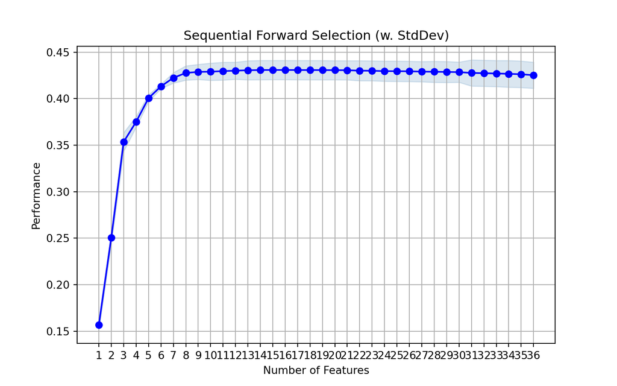

```python
from mlxtend.plotting import plot_sequential_feature_selection as plot_sfs
import matplotlib.pyplot as plt

fig1 = plot_sfs(sfs_back.get_metric_dict(), kind='std_dev')

#plt.ylim([0.8, 1])
plt.title('Sequential Forward Selection (w. StdDev)')
plt.grid()
plt.show()
```

```python
# Sequential Forward Selection
sfs_12 = sfs(clf,
          k_features= 12,
          forward=False,
          floating=True,
          scoring='r2',
          cv=4)

sfs_12 = sfs_12.fit(X_train.drop(['aleatorio2_log'],axis=1), y_train)

print('\nSequential Forward Selection (k=12):')
```

```
##
## Sequential Forward Selection (k=12):
```

```python
print(sfs_12.k_feature_names_)
```

```
## ('Acidez_sqr', 'Alcohol_raiz4', 'CalifProductor_raiz4', 'Clasificacion_**', 'Clasificacion_***', 'Clasificacion_****', 'Clasificacion_Desc', 'Etiqueta_B', 'Etiqueta_M', 'Etiqueta_MB', 'Etiqueta_R', 'Region_2.0')
```

```python
print('CV Score:')
```

```
## CV Score:
```

```python
print(sfs_12.k_score_)
```

```
## 0.4307507834148463
```

```python
# Sequential Forward Selection
sfs_10 = sfs(clf,
          k_features= 10,
          forward=False,
          floating=True,
          scoring='r2',
          cv=4)

sfs_10 = sfs_10.fit(X_train.drop(['aleatorio2_log'],axis=1), y_train)

print('\nSequential Forward Selection (k=10):')
```

```
##
## Sequential Forward Selection (k=10):
```

```python
print(sfs_10.k_feature_names_)
```

```
## ('Alcohol_raiz4', 'CalifProductor_raiz4', 'Clasificacion_**', 'Clasificacion_***', 'Clasificacion_****', 'Etiqueta_B', 'Etiqueta_M', 'Etiqueta_MB', 'Etiqueta_R', 'Region_2.0')
```

```python
print('CV Score:')
```

```
## CV Score:
```

```python
print(sfs_10.k_score_)
```

```
## 0.42992284686010773
```

## Comparación por validación cruzada

Comparamos el rendimiento de los modelos bajo el esquema de validación cruzada repetida creando una función similar a la que ya teníamos pero que, en esta ocasión trabaja sobre objetos de salida de los métodos de selección de variables de tal forma que en base a estos se seleccione el input adecuado y se ajuste el modelo lineal con las varibales seleccionadas.

```python
import seaborn as sns
from sklearn.model_selection import cross_val_score
from sklearn.model_selection import RepeatedKFold
from sklearn.linear_model import LinearRegression

model =LinearRegression()

# Función para comparación por validación cruzada
def cross_val (sfs, data, y, seed=12345):

        X = sfs

        if not isinstance(sfs,pd.DataFrame):
            X = sfs.transform(data)

        # Establecemos esquema de validación fijando random_state (reproducibilidad)
        cv = RepeatedKFold(n_splits=5, n_repeats=20, random_state=seed)

        # Obtenemos los resultados de R2 para cada partición tr-tst
        scores = cross_val_score(model, X, y, cv=cv)

        # Sesgo y varianza
        print('Coeficiente de determinación R2: %.3f (%.3f)' % (np.mean(scores), np.std(scores)))

       # sns.violinplot(y=scores,palette='viridis')

        return(scores)
```

```python
# Ejemplo de uso par aun modelo
# cross_val(sfs_back,imput_dummy,varObjCont)
```

```python
# Creamos lista de fórmulas
list_sfs = [sfs_back,sfs_forw,sfs_12,sfs_10]
list_sfs

# Aplicamos a toda la lista la función creada (devuelve un dataframe pero está transpuesto)
```

```
## [SequentialFeatureSelector(estimator=LinearRegression(), forward=False,
##                           k_features=(1, 36), scoring='r2'), SequentialFeatureSelector(cv=4, estimator=LinearRegression(),
##                           k_features=(1, 36), scoring='r2'), SequentialFeatureSelector(cv=4, estimator=LinearRegression(), floating=True,
##                           forward=False, k_features=(12, 12), scoring='r2'), SequentialFeatureSelector(cv=4, estimator=LinearRegression(), floating=True,
##                           forward=False, k_features=(10, 10), scoring='r2')]
```

```python
list_res = pd.DataFrame(map(lambda x: cross_val(x,imput_dummy,varObjCont, seed=2022),list_sfs))

# Trasnponer dataframe y pasar de wide a long (creando un factor variable con el nombre de cada fórmula de la lista[0,1,2,3])
```

```
## Coeficiente de determinación R2: 0.432 (0.018)
## Coeficiente de determinación R2: 0.429 (0.019)
## Coeficiente de determinación R2: 0.432 (0.018)
## Coeficiente de determinación R2: 0.398 (0.019)
```

```python
results = list_res.T.melt()
results.columns = ['Modelo','R2']
results.head()
```

```
##    Modelo        R2
## 0       0  0.403360
## 1       0  0.459634
## 2       0  0.396370
## 3       0  0.425929
## 4       0  0.461828
```

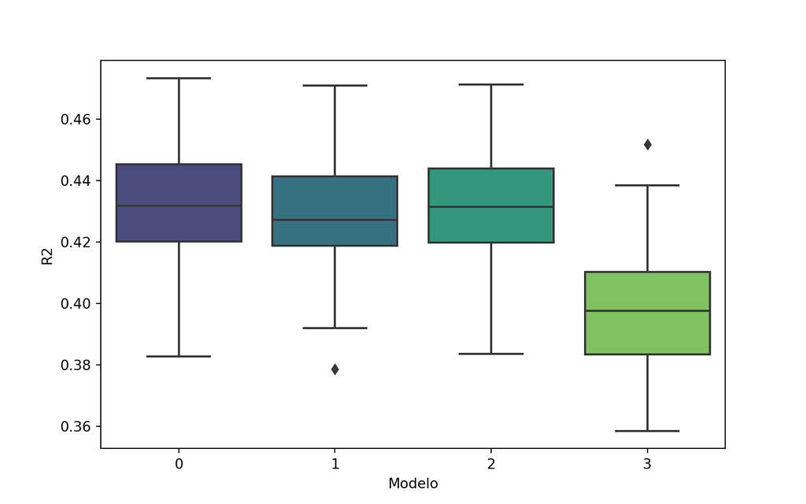

```python
# Boxplot paralelo para comparar
sns.boxplot(x='Modelo',y='R2',data=results,palette='viridis')
```

## Selección de variables con interacciones

Vamos ahora a considerar los efectos de interacción de orden 2 entre las variables para valorar si pueden aportar capacidad predictiva al modelo.

Generaremos el dataset con las interacciones de todas las variables y posteriormente pasaremos los métodos de selección para hacer una criba de efectos interesantes.

```python
sel_col = ['const', 'Acidez', 'CalifProductor',
        'Acidez_sqr', 'Alcohol_raiz4', 'Clasificacion_**', 'Clasificacion_***', 'Clasificacion_****',
        'Clasificacion_Desc', 'Etiqueta_B', 'Etiqueta_M', 'Etiqueta_MB',
        'Etiqueta_R', 'Region_2.0']

imput_red = imput_dummy[sel_col]
X_train_red = X_train[sel_col]
```

```python
from sklearn.preprocessing import OneHotEncoder, PolynomialFeatures

# Create interaction terms (interaction of each regressor pair + polynomial)
#Interaction terms need to be created in both the test and train datasets
interaction = PolynomialFeatures(degree=2, include_bias=False, interaction_only=True)
interaction

#traning
```

```
PolynomialFeatures(include_bias=False, interaction_only=True)
```

```python
imput_inter = pd.DataFrame(interaction.fit_transform(imput_red), columns=interaction.get_feature_names_out(input_features=imput_red.columns))
X_inter = pd.DataFrame(interaction.fit_transform(X_train_red), columns=interaction.get_feature_names_out(input_features=X_train_red.columns))
X_inter.head(3)
```

```
##    const  Acidez  ...  Etiqueta_MB Region_2.0  Etiqueta_R Region_2.0
## 0    1.0    0.13  ...                     0.0                    0.0
## 1    1.0    1.93  ...                     0.0                    0.0
## 2    1.0    0.52  ...                     0.0                    1.0
##
## [3 rows x 105 columns]
```

```python
# Eliminar columnas constantes (interacciones sin sentido)
X_inter = X_inter.loc[:, X_inter.var() != 0.0]

X_inter.head(3)
```

```
##    Acidez  CalifProductor  ...  Etiqueta_MB Region_2.0  Etiqueta_R Region_2.0
## 0    0.13             3.0  ...                     0.0                    0.0
## 1    1.93             2.0  ...                     0.0                    0.0
## 2    0.52             2.0  ...                     0.0                    1.0
##
## [3 rows x 92 columns]
```

```python
# Sequential Forward Selection
sfs_forw_int_10 = sfs(clf,
          k_features=10,
          forward=True,
          floating=False,
          scoring='r2',
          cv=4)

sfs_forw_int_10 = sfs_forw_int_10.fit(X_inter, y_train)

print('\nSequential Backward Selection:')
```

```
##
## Sequential Backward Selection:
```

```python
print(sfs_forw_int_10.k_feature_names_)
```

```
## ('Clasificacion_***', 'Clasificacion_****', 'Etiqueta_MB', 'CalifProductor Alcohol_raiz4', 'CalifProductor Clasificacion_Desc', 'Alcohol_raiz4 Clasificacion_**', 'Alcohol_raiz4 Etiqueta_B', 'Alcohol_raiz4 Etiqueta_M', 'Alcohol_raiz4 Etiqueta_R', 'Clasificacion_Desc Etiqueta_B')
```

```python
print('CV Score:')
```

```
## CV Score:
```

```python
print(sfs_forw_int_10.k_score_)
```

```
## 0.4312610064159307
```

```python
# Sequential Forward Selection
sfs_forw_int_best = sfs(clf,
          k_features='best',
          forward=True,
          floating=False,
          scoring='r2',
          cv=4)

sfs_forw_int_best = sfs_forw_int_best.fit(X_inter, y_train)

print('\nSequential Backward Selection:')
```

```
##
## Sequential Backward Selection:
```

```python
print(sfs_forw_int_best.k_feature_names_)
```

```
## ('Clasificacion_**', 'Clasificacion_***', 'Clasificacion_****', 'Clasificacion_Desc', 'Etiqueta_B', 'Etiqueta_MB', 'Etiqueta_R', 'const Clasificacion_***', 'const Clasificacion_****', 'const Clasificacion_Desc', 'const Etiqueta_M', 'Acidez Clasificacion_**', 'Acidez Clasificacion_****', 'Acidez E…
```

```python
print('CV Score:')
```

```
## CV Score:
```

```python
print(sfs_forw_int_best.k_score_)
```

```
## 0.4358735374591838
```

## Selección de variables por LASSO

Exploramos la selección de variables por modelo laso con criterios AIC o BIC.

```python
from sklearn import linear_model

reg = linear_model.LassoLarsIC(criterion='bic', normalize=False)

reg.fit(X_train, y_train)
```

```
LassoLarsIC(criterion='bic', normalize=False)
```

```python
print(reg.coef_)
```

```
## [ 0.00000000e+00  0.00000000e+00  0.00000000e+00 -1.39519321e-01
##   0.00000000e+00  0.00000000e+00  2.41946622e+00  0.00000000e+00
##   4.25080003e+00 -5.99166747e+00  0.00000000e+00  4.66284521e-01
##   0.00000000e+00  0.00000000e+00 -1.79559227e+00 -3.15962404e-02
##  -2.34448998e-05  0.00000000e+00  0.00000000e+00  0.00000000e+00
##   7.11398854e-03  0.00000000e+00  0.00000000e+00 -1.49412218e-02
##   0.00000000e+00  5.16404290e+00  4.08942378e+01  1.05279112e+02
##   1.75828148e+02 -2.04390299e+01  3.06477428e+02  4.37322938e+01
##   4.01167145e+02  1.75465663e+02  8.45741210e+00  0.00000000e+00]
```

```python
selec_feats = X_train[X_train.columns[(reg.coef_ != 0).ravel().tolist()]]
selec_feats
```

```
##       Azucar    pH  Alcohol  ...  Etiqueta_MB  Etiqueta_R  Region_2.0
## 2225   12.85  4.01      9.4  ...            0           1           0
## 5066    1.80  2.79     10.1  ...            0           1           0
## 3705    2.20  3.40      9.4  ...            0           1           1
## 2043    5.85  3.49     18.9  ...            0           0           0
## 4079    2.60  2.97     10.4  ...            0           1           0
## ...      ...   ...      ...  ...          ...         ...         ...
## 5625    2.30  3.32      3.8  ...            0           0           1
## 613     2.70  4.20      4.7  ...            0           1           0
## 3925    6.20  2.18      9.5  ...            0           1           1
## 4789    6.60  2.69      9.6  ...            0           0           0
## 1102  -24.20  3.18      9.6  ...            0           0           0
##
## [3998 rows x 20 columns]
```

Lasso con interacciones

```python
lasso_int = linear_model.LassoLarsIC(criterion='bic', normalize=False)

lasso_int.fit(X_inter, y_train)
```

```
LassoLarsIC(criterion='bic', normalize=False)
```

```python
print(lasso_int.coef_)
```

```
## [  0.           0.           2.99206822   0.           0.
##    0.           0.           0.           0.           0.
##    0.           0.           0.           0.           0.
##  -19.79271453   0.           0.           0.           0.
##    0.           0.           0.           0.           0.
##    0.           7.00164694   0.45680166   0.           0.
##    0.           0.           0.           0.           0.
##    0.           0.           0.          -1.12289757  -3.42463017
##    3.38335067   7.42006983  26.0183713   -8.06842736   0.
##    2.07213356  30.71328131   0.           1.38219074   0.89840347
##    0.           0.8343615    7.45718719  -0.55263833  12.01026636
##    9.56027812  15.52272861  12.75677011   0.83652     18.30470615
##   44.76628113  38.23146159   0.         139.87600766   0.
##  136.45325037  63.72970105   1.46415804   0.           0.
##    0.           0.           0.           0.           0.
##    0.           0.           0.           0.           0.
##    0.           0.           0.           0.           0.
##    0.           0.           0.           0.           0.
##    0.           0.        ]
```

```python
selec_feats_int = X_inter[X_inter.columns[(lasso_int.coef_ != 0).ravel().tolist()]]
selec_feats_int
```

```
##       Acidez_sqr  ...  Alcohol_raiz4 Region_2.0
## 0       4.752836  ...                  0.000000
## 1      15.841196  ...                  0.000000
## 2       6.605414  ...                  1.750988
## 3       1.960280  ...                  0.000000
## 4       4.040502  ...                  0.000000
## ...          ...  ...                       ...
## 3993    5.570072  ...                  1.396204
## 3994    6.812622  ...                  0.000000
## 3995    3.841992  ...                  1.755626
## 3996    5.856884  ...                  0.000000
## 3997    9.797526  ...                  0.000000
##
## [3998 rows x 29 columns]
```

### Validación Cruzada

```python
list_sfs = [sfs_forw_int_10,sfs_forw_int_best,selec_feats,selec_feats_int]
list_sfs
```

```
## [SequentialFeatureSelector(cv=4, estimator=LinearRegression(),
##                           k_features=(10, 10), scoring='r2'), SequentialFeatureSelector(cv=4, estimator=LinearRegression(),
##                           k_features=(1, 92), scoring='r2'),       Azucar    pH  Alcohol  ...  Etiqueta_MB  Etiqueta_R  Region_2.0
## 2225   12.85  4.01      9.4  ...            0           1           0
## 5066    1.80  2.79     10.1  ...            0           1           0
## 3705    2.20  3.40      9.4  ...            0           1           1
## 2043    5.85  3.49     18.9  ...            0           0           0
## 4079    2.60  2.97     10.4  ...            0           1           0
## ...      ...   ...      ...  ...          ...         ...         ...
## 5625    2.30  3.32      3.8  ...            0           0           1
## 613     2.70  4.20      4.7  ...            0           1           0
## 3925    6.20  2.18      9.5  ...            0           1           1
## 4789    6.60  2.69      9.6  ...            0           0           0
## 1102  -24.20  3.18      9.6  ...            0           0           0
##
## [3998 rows x 20 columns],       Acidez_sqr  ...  Alcohol_raiz4 Region_2.0
## 0       4.752836  ...                  0.000000
## 1      15.841196  ...                  0.000000
## 2       6.605414  ...                  1.750988
## 3       1.960280  ...                  0.000000
## 4       4.040502  ...                  0.000000
## ...          ...  ...                       ...
## 3993    5.570072  ...                  1.396204
## 3994    6.812622  ...                  0.000000
## 3995    3.841992  ...                  1.755626
## 3996    5.856884  ...                  0.000000
## 3997    9.797526  ...                  0.000000
##
## [3998 rows x 29 columns]]
```

```python
data = imput_dummy.join(imput_inter,lsuffix="_left")

# Aplicamos a toda la lista la función creada (devuelve un dataframe pero está transpuesto)
list_res = pd.DataFrame(map(lambda x: cross_val(x,X_inter,y_train, seed=2022),list_sfs))

# Trasnponer dataframe y pasar de wide a long (creando un factor variable con el nombre de cada fórmula de la lista[0,1,2,3])
```

```
## Coeficiente de determinación R2: 0.429 (0.023)
## Coeficiente de determinación R2: 0.429 (0.022)
## Coeficiente de determinación R2: 0.427 (0.023)
## Coeficiente de determinación R2: 0.420 (0.023)
```

```python
results = list_res.T.melt()
results.columns = ['Modelo','R2']
results.head()
```

```
##    Modelo        R2
## 0       0  0.431515
## 1       0  0.385572
## 2       0  0.409845
## 3       0  0.479673
## 4       0  0.441319
```

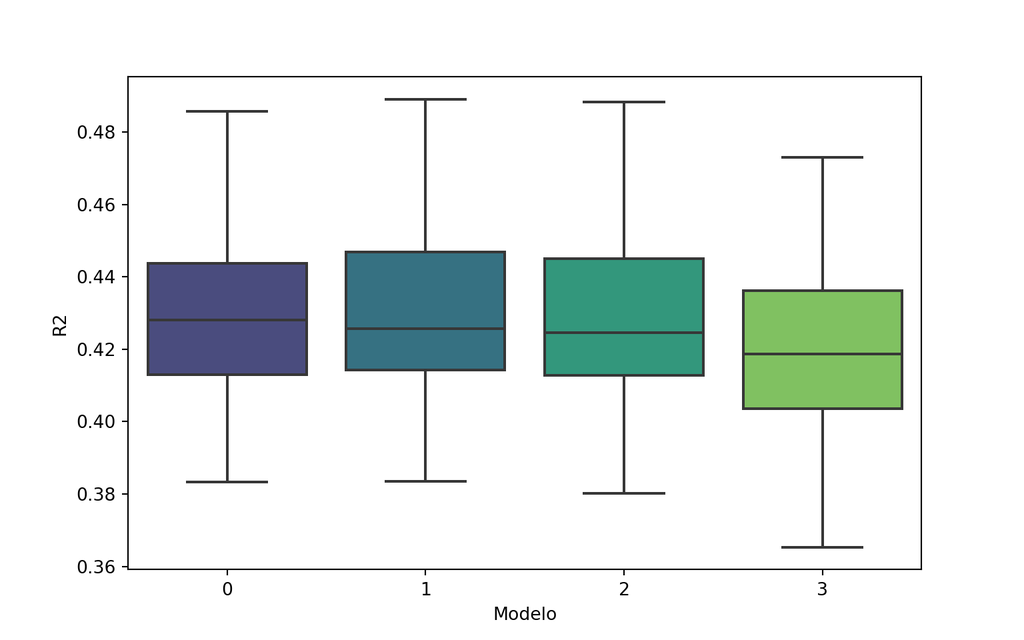

```python
# Boxplot paralelo para comparar
sns.boxplot(x='Modelo',y='R2',data=results,palette='viridis')
```